# Mini exploratory report on juvenile snowshoe hares in Bonanza Creek LTER

Katie Pietrucha

11/10/2021

## 1. Introduction

This report provides an exploratory overview of differences in counts and sizes of juvenile showshoe hares from 1998 - 2012 (Kielland et al. 2017). The hares represented were observed at the Bonanza Creek Experimental Forest near Fairbanks, Alaska, which is part of the US Long Term Ecological Research Network. Specifically, hare counts are compared annually across the length of the study, weights are compared by sex and sampling site, and the relationship between weight and hind foot length is explored.

## 2. Data and analyses

Snowshoe hare physical data was collected and made available by Dr. Knut Kielland and colleagues at the Bonanza Creek Long-Term Ecological Research (LTER) network site, specifically the Bonanza Creek Experimental Forest, 20 km southwest of Fairbanks, Alaska (Kielland et al. 2017). The data contain observations for snowshoe hares trapped at 3 sampling sites between 1998 and 2012. In exploratory data visualizations, juvenile hare trappings are compared annually across the years included in the study, and juvenile hare weights are compared by sex and sampling site. The difference in weights between male and female hares is evaluated using a two-sample t-test (using a significance level (α) of 0.05), and the differences between groups are described by Cohen’s d effect size. The relationship between weight and hind foot length is explored by simple linear regression. All analyses are in R version 4.1.1 using RStudio version 1.4.1717.

## 3. Preliminary results from juvenile hare initial investigation

### A. Annual juvenile hare trap counts

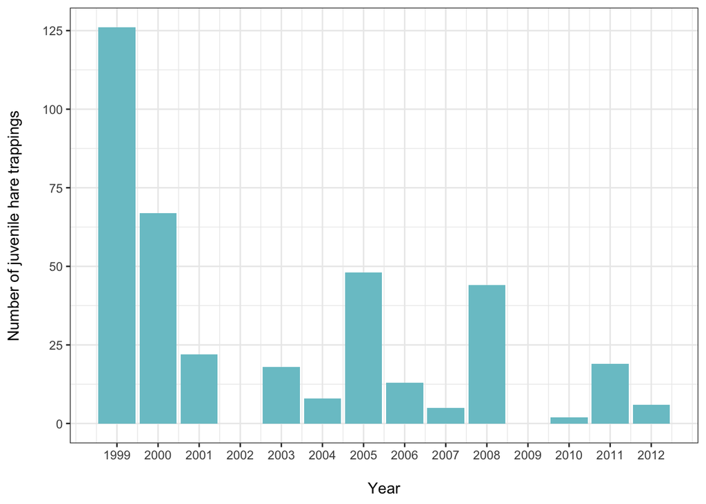

**Figure 1:** Total number of juvenile hare trappings by year (1999-2012). Data: Kielland et al. 2017.

Annual juvenile hare trappings were compared from 1999-2012. Total juvenile hare trappings varied considerably by year, with the most trapped in 1999, and a general decrease in hares trapped over the course of the study. In some years, no juvenile hares were trapped – 1998 (not shown), 2002, and 2009. The minimum juvenile hare count (> 0) was 2 and the maximum juvenile hare count was 126. The mean number of juvenile hares trapped annually is 31.5, and the median is 18.5. To standardize the juvenile hare population in future analyses, I would recommend calculating the number of juvenile hares trapped per number of traps placed or number of study days per year. This would eliminate the effect of varying annual efforts on the counts and make the count value intensive.

### B. Difference in hare weights by sex and grid (sampling site)

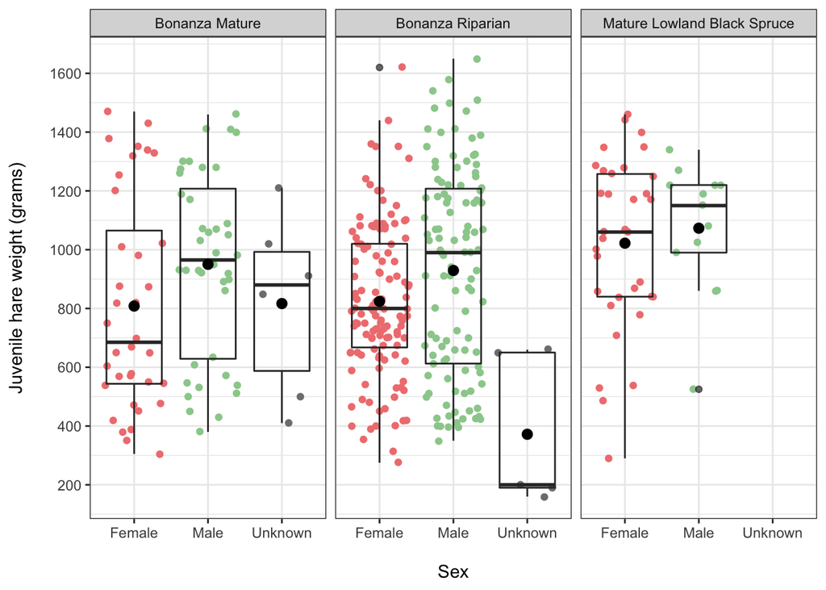

**Figure 2:** Juvenile hare weights (g) by sex and sampling site. Each point is a single observation. Box endpoints indicate the 25th and 75th percentile values; the black line and black point within the box indicate the median and mean value for each sex, respectively. Hares recorded with a sex of ‘NA’ are represented by the ‘Unknown’ category. Data: Kielland et al. 2017.

The most juvenile hares were trapped at the Bonanza Riparian site, which may indicate their preferred habitat. The mean and median weights do vary by sex and can be compared by looking across the black points and lines at each site. Males and female weights appear to have similar means in the Bonanza Mature and Bonanza Riparian zones, while in the Mature Lowland Black Spruce site, the means appear to be larger for each sex. The significance of this difference and possible mechanisms behind it should be explored in a future study.

### C. Difference in juvenile weight between male and female snowshoe hares

**Table 1: Means comparison of male and female juvenile snowshoe hare weights**: Male juvenile hares have a larger mean weight than female juveniles. The male mean weight also has a larger standard deviation but less males were sampled.

| Sex | Mean (g) | Standard Deviation (g) | Sample Size |
| --- | --- | --- | --- |
| Female | 855.39 | 292.25 | 197 |
| Male | 945.86 | 333.22 | 163 |

The male mean weight (945.86) is 90.47 grams larger than the female mean weight (855.39). The effect size is small (0.29) and the difference significant (two-sample t-test: t = 2.71, p < 0.007).

### D. Relationship between juvenile weight & hind foot length

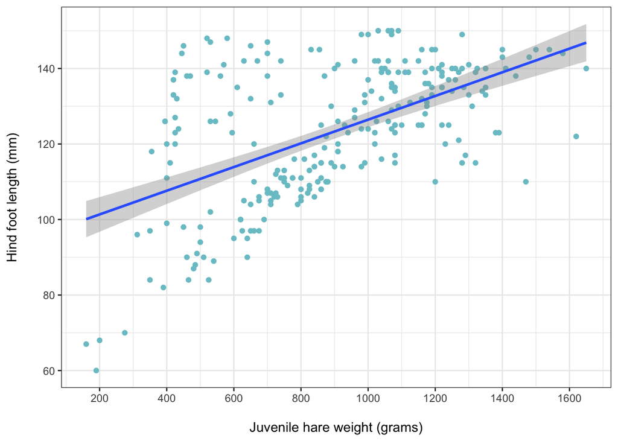

## 4. Summary

Next steps:

- Compare hind foot lengths statistically (one-way ANOVA), including hare sex as a covariate.
- Multiple linear regression to understand the relationship between sex, site, hind foot length and body mass.
- Statistically comparing the difference in mean weights from all sites sampled (one-way ANOVA), and specifically compare the mean weights from the Mature Lowland Black Spruce site to the mean weights of the other sites combined (two-sample t-test).
- Explore other ways to model the relationship between hind foot length and body weight, since the assumption of homoscedasticity for a linear model appears to be violated.

## 5. Citations

**Data citation:** Kielland, K., F.S. Chapin, R.W. Ruess, and Bonanza Creek LTER. 2017. Snowshoe hare physical data in Bonanza Creek Experimental Forest: 1999-Present ver 22. Environmental Data Initiative. https://doi.org/10.6073/pasta/03dce4856d79b91557d8e6ce2cbcdc14